# Supervised machine learning models

## Understanding the data

The data set available to us consists of 80,000 rows of loan default data. The variable can be bucketed into types such as:

- Applicant data: Age, education, os_type and so on
- Credit data: credit checks, credict card limit, debit card score and so on.
- Call data: calls made, service calls, high risk calls and so on.
- Loan data: loan term, loan amount, and so on.

We go through the following steps to clean the data:

```python
import pandas as pd
import numpy as np
import seaborn as sns
import matplotlib.pyplot as plt
import re

%matplotlib inline
```

```python
data = pd.read_csv('loan_default.csv')
data.head()
```

|  | Unnamed: 0 | Unnamed: 0.1 | id | loan_default | AP001 | AP002 | AP003 | AP004 | AP005 | AP006 | ... | CD162 | CD164 | CD166 | CD167 | CD169 | CD170 | CD172 | CD173 | MB005 | MB007 |
| --- | --- | --- | --- | --- | --- | --- | --- | --- | --- | --- | --- | --- | --- | --- | --- | --- | --- | --- | --- | --- | --- |
| 0 | 0 | 1 | 1 | 1 | 31 | 2 | 1 | 12 | 2017/7/6 10:21 | ios | ... | 13.0 | 13.0 | 0.0 | 0.0 | 1449.0 | 1449.0 | 2249.0 | 2249.0 | 7.0 | IPHONE7 |
| 1 | 1 | 2 | 2 | 0 | 27 | 1 | 1 | 12 | 2017/4/6 12:51 | h5 | ... | -99.0 | -99.0 | -99.0 | -99.0 | -99.0 | -99.0 | -99.0 | -99.0 | NaN | WEB |
| 2 | 2 | 3 | 3 | 0 | 33 | 1 | 4 | 12 | 2017/7/1 14:11 | h5 | ... | 3.0 | 2.0 | 33.0 | 0.0 | 33.0 | 0.0 | 143.0 | 110.0 | 8.0 | WEB |
| 3 | 3 | 4 | 4 | 0 | 34 | 2 | 4 | 12 | 2017/7/7 10:10 | android | ... | 0.0 | 0.0 | 0.0 | 0.0 | 0.0 | 0.0 | 0.0 | 0.0 | 10.0 | OPPO |
| 4 | 4 | 5 | 5 | 0 | 47 | 2 | 1 | 12 | 2017/7/6 14:37 | h5 | ... | -99.0 | -99.0 | -99.0 | -99.0 | -99.0 | -99.0 | -99.0 | -99.0 | NaN | WEB |

5 rows × 89 columns

```python
#renaming columns to more readable ones
oldnames = data.columns.tolist()
newnames = ["X", "unnamed", "id", "loan_default", "age_yr", "gender", "education", "loan_term", "date_applied", "OS_type", "app_city_level",
               "ip_appl_mismatch", "ap009", "cq_p2p_7d", "cq_sl_7d", "cq_p2p_1m", "cq_sl_1m", "cq_p2p_3m", "cq_sl_3m", "cq_p2p_6m", "cq_sl_6m", "cq_bank_6m",
               "count_hit_r6", "count_hit_r7", "count_hit_r8", "td025", "td026", "td027", "td028", "td029", "td044", "td048", "td051",
                "td054", "td055", "td061", "td062", "cq_time_1m", "cq_time_2m", "t_loan_amount", "cc_flag_8", "cc_mob_max_m", "dc_amount_score",
               "dc_utility_score", "dc_limit_score", "days_app_fhr", "days_app_fcc", "avg_len_chr_call", "avg_len_chr_call_in",
               "avg_len_chr_call_out", "avg_len_c_call","total_in_call_1m", "total_out_call_3m", "family_in_call_3m", "family_out_call_3m",
               "count_col_call_3m", "count_abnormal_call_2m", "count_abnormal_in_call_2m", "count_abnormal_call_3m", "count_abnormal_in_call_3m", "count_abnormal_out_call_3m",
               "count_abcall_day_2m", "count_abcall_day_3m", "distinct_call_1m", "distinct_out_call_1m", "distinct_call_2m", "distinct_out_call_2m", "distinct_call_3m", "distinct_out_call_3m",
               "freqout_in_call_2m", "freqin_out_call_2m", "freqout_out_call_2m", "freqin_in_call_2m", "freqout_in_call_3m", "freqin_out_call_3m", "freqout_out_call_3m", "len_freqout_out_call_3m", "len_freqin_in_call_3m",
               "count_service_out_call_2m", "count_service_call_3m", "count_service_out_call_3m", "len_service_call_1m", "len_service_out_call_1m", "len_service_call_2m", "len_service_out_call_2m",
               "len_service_call_3m", "len_service_out_call_3m", "years_phone_active", "mob_brand"]

data.rename(columns = {oldnames[i] : newnames[i] for i in range(len(oldnames))}, errors = 'raise', inplace = True)

#removing date and additional id columns
a = list(range(2,89))
a.remove(8)
data = data.iloc[:, a]
data.head()

#creating new dataset with fixed types
data1 = data.copy()
```

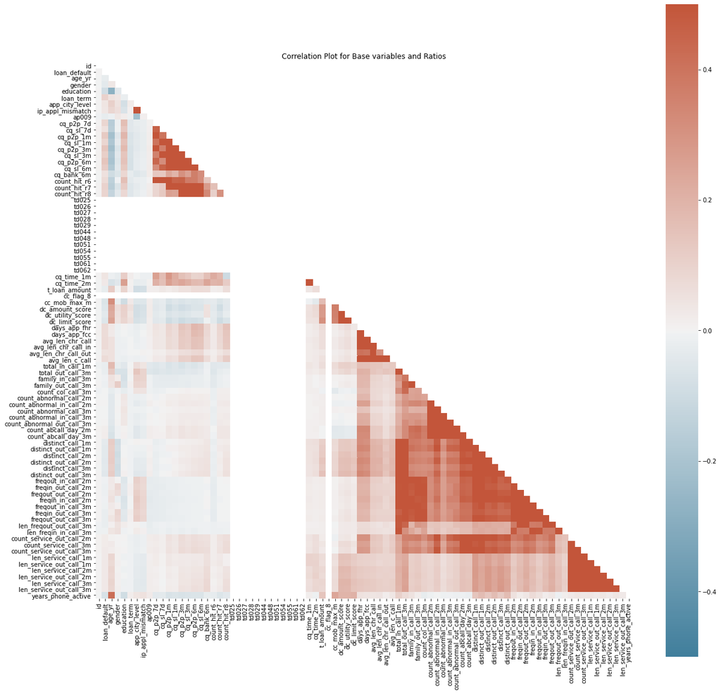

```python
corr = data.corr()
plt.figure(figsize = (20, 20))
mask = np.triu(np.ones_like(corr, dtype = bool ))
cmap = sns.diverging_palette(230, 20,  as_cmap = True)
sns.heatmap(corr, mask = mask, cmap = cmap, square = True, annot= False, vmax= 0.5, vmin = -0.5, center= 0.00)
plt.title('Correlation Plot for Base variables and Ratios')
```

```python
def data_clean(data1):
    #Fixing the following datatypes to factors
    data1['gender'] = data1['gender'].astype(str)
    data1['loan_term'] = data1['loan_term'].astype(str)
    data1['education'] = data1['education'].astype(str)
    data1['OS_type'] = data1['OS_type'].astype(str)
    data1['app_city_level'] = data1['app_city_level'].astype(str)
    data1['ip_appl_mismatch'] = data1['ip_appl_mismatch'].astype(str)
    data1['ap009'] = data1['ap009'].astype(str)
    data1['mob_brand'] = data1['mob_brand'].astype(str)
    #creating a new variable mismatch to see if there is a mismatch between the level of the ip address and the application city
    data1['mismatch'] = np.where(data1['app_city_level'] == data1['ip_appl_mismatch'], 1, 0)
    #dropping columns which do not add any value based on earlier EDA
    #drop_cols = ["td025", "td026", "td027", "td028", "td029", "td044", "td048", "td051", "td054", "td055", "td061", "td062", "cc_flag_8","cq_p2p_1m", "cq_sl_1m","cq_p2p_3m", "cq_sl_3m"]
    #data1.drop(drop_cols, axis = 1, inplace = True)
    #replacing categories in mobile brands
    data1['mob_brand'] = data1['mob_brand'].str.replace("IPHONE\\d", 'Iphone') #cleaning up iphone levels
    data1['mob_brand'] = data1['mob_brand'].str.replace("IPAD\\d", 'Iphone') #cleaning up iphone levels
    data1['mob_brand'] = data1['mob_brand'].str.lower() #converting all brands to lower
    other_brands = pd.Series(["web", "iphone", "oppo", "noinfo", "vivo", "huawei", "samsung", "xiaomi", "honor", "meizu",
                "gionee", "leeco", "letv", "360", "coolpad"]) #creating top 15 brands
    data1['mob_brand'] = data1['mob_brand'].apply(lambda x: x if any([k == x for k in other_brands]) else 'other') #rebucketing all other brands
    #creating a new variable phone missing for missing active phone yeards data
    data1['phone_missing'] = data1['years_phone_active'].apply(lambda x: 1 if np.isnan(x) else 0)
    #creating new variables for rows with missing data
    data1['nodata_1'] = data1['total_in_call_1m'].apply(lambda x: 1 if np.isnan(x) else 0)
    data1['nodata_2'] = data1['count_hit_r6'].apply(lambda x: 1 if np.isnan(x) else 0)
    #Creating index of columns with null values
    null_col = data1.isnull().sum().sort_values(ascending = False)
    null_col = null_col[ null_col > 0]
    #Looping through to replace NAs with mean values
    null_col = null_col.index
    for col in null_col:
        data1.loc[:, col].fillna(0, inplace = True)
    return data1

def train_binning(data1):
    #binning age, phone usage and loan term data and creating bins for use in next function
    data1['age_yr_bin'], year_bin = pd.qcut(data1['age_yr'], q = 10, precision = 0, retbins= True)
    year_bin = np.concatenate(([-np.inf], year_bin[1:-1], [np.inf]))
    data1['t_loan_amount_bin'], loan_bin = pd.qcut(data1['t_loan_amount'], q = 5, precision = 0, retbins = True)
    loan_bin = np.concatenate(([-np.inf], loan_bin[1:-1], [np.inf]))
    data1['years_phone_active_bins'], phone_bin = pd.qcut(data1['years_phone_active'], q = 5, precision = 0, retbins = True)
    phone_bin = np.concatenate(([-np.inf], phone_bin[1:-1], [np.inf]))
    data1.drop(['age_yr', 't_loan_amount', 'years_phone_active', "cq_sl_1m", "cq_p2p_3m", "cq_sl_3m", "cq_p2p_6m", "cq_sl_6m", "cq_bank_6m", "cq_time_2m", "count_abnormal_call_3m",
                "dc_utility_score", "dc_limit_score", "days_app_fcc", "avg_len_chr_call", "avg_len_chr_call_in", "count_abnormal_in_call_3m", "count_abnormal_out_call_3m",
                "count_abcall_day_2m", "count_abcall_day_3m", "freqin_out_call_3m", "freqout_out_call_3m", "distinct_call_1m", "distinct_out_call_1m", "distinct_call_2m",
                "len_freqout_out_call_3m", "len_freqin_in_call_3m", "count_service_out_call_2m", "count_service_call_3m", "count_service_out_call_3m",
                "len_service_call_1m"], axis = 1, inplace = True) #remove high correlation variables
    return data1, year_bin, loan_bin, phone_bin

def test_binning(data1, year_bin, loan_bin, phone_bin):
    data1['age_yr_bin'] = pd.cut(data1['age_yr'], year_bin)
    data1['t_loan_amount_bin'] = pd.cut(data1['t_loan_amount'], loan_bin)
    data1['years_phone_active_bins'] = pd.cut(data1['years_phone_active'], phone_bin)
    data1.drop(['age_yr', 't_loan_amount', 'years_phone_active', "cq_sl_1m", "cq_p2p_3m", "cq_sl_3m", "cq_p2p_6m", "cq_sl_6m", "cq_bank_6m", "cq_time_2m", "count_abnormal_call_3m",
                "dc_utility_score", "dc_limit_score", "days_app_fcc", "avg_len_chr_call", "avg_len_chr_call_in", "count_abnormal_in_call_3m", "count_abnormal_out_call_3m",
                "count_abcall_day_2m", "count_abcall_day_3m", "freqin_out_call_3m", "freqout_out_call_3m", "distinct_call_1m", "distinct_out_call_1m", "distinct_call_2m",
                "len_freqout_out_call_3m", "len_freqin_in_call_3m", "count_service_out_call_2m", "count_service_call_3m", "count_service_out_call_3m",
                "len_service_call_1m"], axis = 1, inplace = True)
    return data1
```

## Setting up train and test sets for modeling

We use scikit learns train_test_split function to create train and test datasets for modelling.

We also use the functions built in the previous section to clean the dataset and build and include only required features, and to build a list of the predictor columns and set the target to loan default.

```python
#Creating train and test datasets
from sklearn.model_selection import train_test_split

train, test = train_test_split(data1,test_size=0.2, random_state = 257)
```

```python
%%capture [--no-stderr]

train = data_clean(train)
test = data_clean(test)
train, t_year_bin, t_loan_bin, t_phone_bin = train_binning(train)
test = test_binning(test, t_year_bin, t_loan_bin, t_phone_bin)
```

```python
target = 'loan_default'
predictors = train.columns.tolist()
predictors.remove('loan_default')
predictors.remove('id')
```

```python
train.shape
```

```
(64000, 62)
```

```python
test.shape
```

```
(16000, 62)
```

Now that we have 80% of the data in train and 20% in test, we will initiate h2o clusters and setup functions required for creating our classification model using the random forest algorithm.

## Setting up the algorithm

We set up the algorithm through the following steps:

- Initiate h2o clusters
- create a function to identify important variables
- create a function to build a gains table
- create a function to plot AUC and precision curves

We also create a sample dataset with 10% of the data and run the random forest estimator and functions to check if they work properly

```python
import h2o
h2o.init()
```

[output not shown]

| H2O_cluster_uptime: | 03 secs |
| --- | --- |
| H2O_cluster_timezone: | America/New_York |
| H2O_data_parsing_timezone: | UTC |
| H2O_cluster_version: | 3.30.1.3 |
| H2O_cluster_version_age: | 1 month and 5 days |
| H2O_cluster_name: | H2O_from_python_karth_r0wh7u |
| H2O_cluster_total_nodes: | 1 |
| H2O_cluster_free_memory: | 1.719 Gb |
| H2O_cluster_total_cores: | 8 |
| H2O_cluster_allowed_cores: | 8 |
| H2O_cluster_status: | accepting new members, healthy |
| H2O_connection_url: | http://127.0.0.1:54321 |
| H2O_connection_proxy: | {"http": null, "https": null, "no": "192.168.99.100"} |
| H2O_internal_security: | False |
| H2O_API_Extensions: | Amazon S3, Algos, AutoML, Core V3, TargetEncoder, Core V4 |
| Python_version: | 3.8.6 final |

```python
from h2o.estimators.gbm import H2OGradientBoostingEstimator
from h2o.estimators.random_forest import H2ORandomForestEstimator
import warnings
warnings.filterwarnings('ignore')
```

```python
def VarImp(model_name):

    from sklearn.metrics import roc_curve,auc
    from sklearn.metrics import average_precision_score
    from sklearn.metrics import precision_recall_curve
    import matplotlib.pyplot as plt

    # plot the variable importance
    plt.rcdefaults()
    variables = model_name._model_json['output']['variable_importances']['variable']
    y_pos = np.arange(len(variables))
    fig, ax = plt.subplots(figsize = (6,len(variables)/2))
    scaled_importance = model_name._model_json['output']['variable_importances']['scaled_importance']
    ax.barh(y_pos,scaled_importance,align='center',color='green')
    ax.set_yticks(y_pos)
    ax.set_yticklabels(variables)
    ax.invert_yaxis()
    ax.set_xlabel('Scaled Importance')
    ax.set_title('Variable Importance')
    plt.show()

def createGains(model):
    predictions = model.predict(test_hex)
    test_scores = test_hex['loan_default'].cbind(predictions).as_data_frame()

    #sort on prediction (descending), add id, and decile for groups containing 1/10 of datapoints
    test_scores = test_scores.sort_values(by='predict',ascending=False)
    test_scores['row_id'] = range(0,0+len(test_scores))
    test_scores['decile'] = ( test_scores['row_id'] / (len(test_scores)/10) ).astype(int)
    #see count by decile
    test_scores.loc[test_scores['decile'] == 10]=9
    test_scores['decile'].value_counts()

    #create gains table
    gains = test_scores.groupby('decile')['loan_default'].agg(['count','sum'])
    gains.columns = ['count','actual']
    gains

    #add features to gains table
    gains['non_actual'] = gains['count'] - gains['actual']
    gains['cum_count'] = gains['count'].cumsum()
    gains['cum_actual'] = gains['actual'].cumsum()
    gains['cum_non_actual'] = gains['non_actual'].cumsum()
    gains['percent_cum_actual'] = (gains['cum_actual'] / np.max(gains['cum_actual'])).round(2)
    gains['percent_cum_non_actual'] = (gains['cum_non_actual'] / np.max(gains['cum_non_actual'])).round(2)
    gains['if_random'] = np.max(gains['cum_actual']) /10
    gains['if_random'] = gains['if_random'].cumsum()
    gains['lift'] = (gains['cum_actual'] / gains['if_random']).round(2)
    gains['K_S'] = np.abs( gains['percent_cum_actual'] -  gains['percent_cum_non_actual'] ) * 100
    gains['gain']=(gains['cum_actual']/gains['cum_count']*100).round(2)
    gains = pd.DataFrame(gains)
    return(gains)

def ROC_AUC(my_result,df,target):
    from sklearn.metrics import roc_curve,auc
    from sklearn.metrics import average_precision_score
    from sklearn.metrics import precision_recall_curve
    import matplotlib.pyplot as plt

    # ROC
    y_actual = df[target].as_data_frame()
    y_pred = my_result.predict(df).as_data_frame()
    fpr = list()
    tpr = list()
    roc_auc = list()
    fpr,tpr,_ = roc_curve(y_actual,y_pred)
    roc_auc = auc(fpr,tpr)

    # Precision-Recall
    average_precision = average_precision_score(y_actual,y_pred)

    print('')
    print('   * ROC curve: The ROC curve plots the true positive rate vs. the false rositive sate')
    print('')
    print('	  * The area under the curve (AUC): A value between 0.5 (random) and 1.0 (perfect), measuring the prediction accuracy')
    print('')
    print('   * Recall (R) = The number of true positives / (the number of true positives + the number of false negatives)')
    print('')

    # plotting
    plt.figure(figsize=(10,4))

    # ROC
    plt.subplot(1,2,1)
    plt.plot(fpr,tpr,color='darkorange',lw=2,label='ROC curve (area=%0.2f)' % roc_auc)
    plt.plot([0,1],[0,1],color='navy',lw=3,linestyle='--')
    plt.xlim([0.0,1.0])
    plt.ylim([0.0,1.05])
    plt.xlabel('False Positive Rate')
    plt.ylabel('True Positive Rate')
    plt.title('Receiver operating characteristic: AUC={0:0.4f}'.format(roc_auc))
    plt.legend(loc='lower right')

    # Precision-Recall
    plt.subplot(1,2,2)
    precision,recall,_ = precision_recall_curve(y_actual,y_pred)
    plt.step(recall,precision,color='b',alpha=0.2,where='post')
    plt.fill_between(recall,precision,step='post',alpha=0.2,color='b')
    plt.xlabel('Recall')
    plt.ylabel('Precision')
    plt.ylim([0.0,1.05])
    plt.xlim([0.0,1.0])
    plt.title('Precision-Recall curve: PR={0:0.4f}'.format(average_precision))
    plt.show()
```

```python
target = 'loan_default'
train_smpl = train.sample(frac=0.1, random_state=1)
test_smpl = test.sample(frac=0.1, random_state=1)
train_hex = h2o.H2OFrame(train_smpl)
test_hex = h2o.H2OFrame(test_smpl)
```

```
Parse progress: |█████████████████████████████████████████████████████████| 100%
Parse progress: |█████████████████████████████████████████████████████████| 100%
```

```python
rf_test = H2ORandomForestEstimator(
        model_id = 'rf_test',
        ntrees = 300,
        nfolds=10,
        min_rows=100,
        seed=1234)
rf_test.train(predictors,target,training_frame=train_hex)
```

```
drf Model Build progress: |███████████████████████████████████████████████| 100%
```

```python
createGains(rf_test)
```

```
drf prediction progress: |████████████████████████████████████████████████| 100%
```

| decile | count | actual | non_actual | cum_count | cum_actual | cum_non_actual | percent_cum_actual | percent_cum_non_actual | if_random | lift | K_S | gain |
| --- | --- | --- | --- | --- | --- | --- | --- | --- | --- | --- | --- | --- |
| 0 | 160 | 72 | 88 | 160 | 72 | 88 | 0.23 | 0.07 | 31.7 | 2.27 | 16.0 | 45.00 |
| 1 | 160 | 43 | 117 | 320 | 115 | 205 | 0.36 | 0.16 | 63.4 | 1.81 | 20.0 | 35.94 |
| 2 | 160 | 46 | 114 | 480 | 161 | 319 | 0.51 | 0.25 | 95.1 | 1.69 | 26.0 | 33.54 |
| 3 | 160 | 37 | 123 | 640 | 198 | 442 | 0.62 | 0.34 | 126.8 | 1.56 | 28.0 | 30.94 |
| 4 | 160 | 30 | 130 | 800 | 228 | 572 | 0.72 | 0.45 | 158.5 | 1.44 | 27.0 | 28.50 |
| 5 | 160 | 23 | 137 | 960 | 251 | 709 | 0.79 | 0.55 | 190.2 | 1.32 | 24.0 | 26.15 |
| 6 | 160 | 18 | 142 | 1120 | 269 | 851 | 0.85 | 0.66 | 221.9 | 1.21 | 19.0 | 24.02 |
| 7 | 160 | 19 | 141 | 1280 | 288 | 992 | 0.91 | 0.77 | 253.6 | 1.14 | 14.0 | 22.50 |
| 8 | 160 | 17 | 143 | 1440 | 305 | 1135 | 0.96 | 0.88 | 285.3 | 1.07 | 8.0 | 21.18 |
| 9 | 160 | 12 | 148 | 1600 | 317 | 1283 | 1.00 | 1.00 | 317.0 | 1.00 | 0.0 | 19.81 |

```
drf prediction progress: |████████████████████████████████████████████████| 100%

   * ROC curve: The ROC curve plots the true positive rate vs. the false rositive sate

	  * The area under the curve (AUC): A value between 0.5 (random) and 1.0 (perfect), measuring the prediction accuracy

   * Recall (R) = The number of true positives / (the number of true positives + the number of false negatives)
```

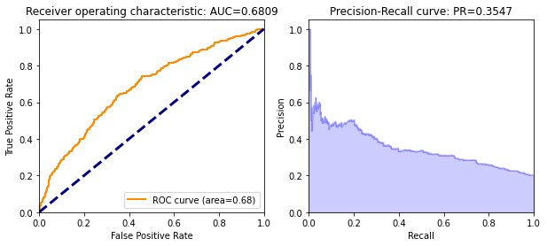

```python
ROC_AUC(rf_test, test_hex, 'loan_default')
```

## Creating our first full classificaion model

Now, we use the full train and test data to build a full model using all the features to build our initial model.

```python
target = 'loan_default'
train_hex = h2o.H2OFrame(train)
test_hex = h2o.H2OFrame(test)
```

```
Parse progress: |█████████████████████████████████████████████████████████| 100%
Parse progress: |█████████████████████████████████████████████████████████| 100%
```

```python
rf_model1 = H2ORandomForestEstimator(
        model_id = 'rf_model1',
        ntrees = 300,
        nfolds=10,
        min_rows=100,
        seed=1234)
rf_model1.train(predictors,target,training_frame=train_hex)
```

```
drf Model Build progress: |███████████████████████████████████████████████| 100%
```

```python
createGains(rf_model1)
```

```
drf prediction progress: |████████████████████████████████████████████████| 100%
```

| decile | count | actual | non_actual | cum_count | cum_actual | cum_non_actual | percent_cum_actual | percent_cum_non_actual | if_random | lift | K_S | gain |
| --- | --- | --- | --- | --- | --- | --- | --- | --- | --- | --- | --- | --- |
| 0 | 1600 | 647 | 953 | 1600 | 647 | 953 | 0.21 | 0.07 | 310.0 | 2.09 | 14.0 | 40.44 |
| 1 | 1600 | 476 | 1124 | 3200 | 1123 | 2077 | 0.36 | 0.16 | 620.0 | 1.81 | 20.0 | 35.09 |
| 2 | 1600 | 421 | 1179 | 4800 | 1544 | 3256 | 0.50 | 0.25 | 930.0 | 1.66 | 25.0 | 32.17 |
| 3 | 1600 | 363 | 1237 | 6400 | 1907 | 4493 | 0.62 | 0.35 | 1240.0 | 1.54 | 27.0 | 29.80 |
| 4 | 1600 | 307 | 1293 | 8000 | 2214 | 5786 | 0.71 | 0.45 | 1550.0 | 1.43 | 26.0 | 27.68 |
| 5 | 1600 | 256 | 1344 | 9600 | 2470 | 7130 | 0.80 | 0.55 | 1860.0 | 1.33 | 25.0 | 25.73 |
| 6 | 1600 | 231 | 1369 | 11200 | 2701 | 8499 | 0.87 | 0.66 | 2170.0 | 1.24 | 21.0 | 24.12 |
| 7 | 1600 | 186 | 1414 | 12800 | 2887 | 9913 | 0.93 | 0.77 | 2480.0 | 1.16 | 16.0 | 22.55 |
| 8 | 1600 | 139 | 1461 | 14400 | 3026 | 11374 | 0.98 | 0.88 | 2790.0 | 1.08 | 10.0 | 21.01 |
| 9 | 1600 | 74 | 1526 | 16000 | 3100 | 12900 | 1.00 | 1.00 | 3100.0 | 1.00 | 0.0 | 19.38 |

```
drf prediction progress: |████████████████████████████████████████████████| 100%

   * ROC curve: The ROC curve plots the true positive rate vs. the false rositive sate

	  * The area under the curve (AUC): A value between 0.5 (random) and 1.0 (perfect), measuring the prediction accuracy

   * Recall (R) = The number of true positives / (the number of true positives + the number of false negatives)
```

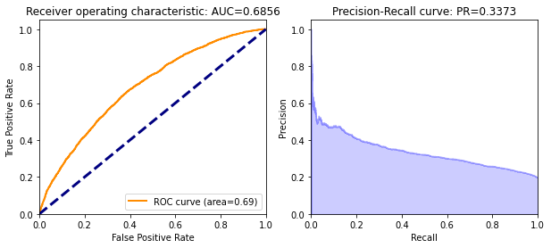

```python
ROC_AUC(rf_model1, test_hex, 'loan_default')
```

## Building a second model with only the important features

Now that we have a base initial model, we attempt to build a second model using only the important variables identified in model1. Let us see if this improves performance.

```python
ignore_col = rf_model1._model_json['output']['variable_importances'].as_data_frame().tail(50)['variable'].to_list()
preds2 = predictors.copy()
for col in ignore_col:
    preds2.remove(col)
```

```python
rf_model2 = H2ORandomForestEstimator(
        model_id = 'rf_model2',
        ntrees = 300,
        nfolds=10,
        min_rows=100,
        seed=1234)
rf_model2.train(preds2,target,training_frame=train_hex)
```

```
drf Model Build progress: |███████████████████████████████████████████████| 100%
```

```python
createGains(rf_model2)
```

```
drf prediction progress: |████████████████████████████████████████████████| 100%
```

| decile | count | actual | non_actual | cum_count | cum_actual | cum_non_actual | percent_cum_actual | percent_cum_non_actual | if_random | lift | K_S | gain |
| --- | --- | --- | --- | --- | --- | --- | --- | --- | --- | --- | --- | --- |
| 0 | 1600 | 592 | 1008 | 1600 | 592 | 1008 | 0.19 | 0.08 | 310.0 | 1.91 | 11.0 | 37.00 |
| 1 | 1600 | 444 | 1156 | 3200 | 1036 | 2164 | 0.33 | 0.17 | 620.0 | 1.67 | 16.0 | 32.38 |
| 2 | 1600 | 405 | 1195 | 4800 | 1441 | 3359 | 0.46 | 0.26 | 930.0 | 1.55 | 20.0 | 30.02 |
| 3 | 1600 | 333 | 1267 | 6400 | 1774 | 4626 | 0.57 | 0.36 | 1240.0 | 1.43 | 21.0 | 27.72 |
| 4 | 1600 | 317 | 1283 | 8000 | 2091 | 5909 | 0.67 | 0.46 | 1550.0 | 1.35 | 21.0 | 26.14 |
| 5 | 1600 | 284 | 1316 | 9600 | 2375 | 7225 | 0.77 | 0.56 | 1860.0 | 1.28 | 21.0 | 24.74 |
| 6 | 1600 | 242 | 1358 | 11200 | 2617 | 8583 | 0.84 | 0.67 | 2170.0 | 1.21 | 17.0 | 23.37 |
| 7 | 1600 | 242 | 1358 | 12800 | 2859 | 9941 | 0.92 | 0.77 | 2480.0 | 1.15 | 15.0 | 22.34 |
| 8 | 1600 | 158 | 1442 | 14400 | 3017 | 11383 | 0.97 | 0.88 | 2790.0 | 1.08 | 9.0 | 20.95 |
| 9 | 1600 | 83 | 1517 | 16000 | 3100 | 12900 | 1.00 | 1.00 | 3100.0 | 1.00 | 0.0 | 19.38 |

```
drf prediction progress: |████████████████████████████████████████████████| 100%

   * ROC curve: The ROC curve plots the true positive rate vs. the false rositive sate

	  * The area under the curve (AUC): A value between 0.5 (random) and 1.0 (perfect), measuring the prediction accuracy

   * Recall (R) = The number of true positives / (the number of true positives + the number of false negatives)
```

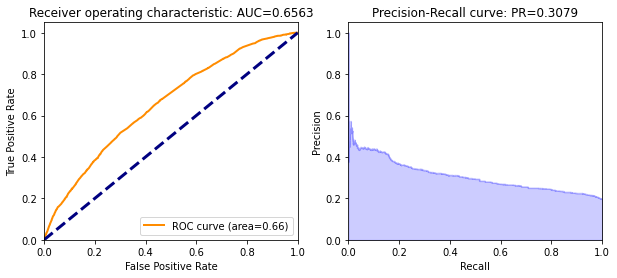

```python
ROC_AUC(rf_model2, test_hex, 'loan_default')
```

However, AUC and precision curve areas are marginally lower.

## Hyper Parameter Tuning.

Since using full predictors seems to have a better effect, lets use all features to tune hyperparameters. We will use h2o package's gridsearch algorithm to run the algorithm through a series of models covering different values for ntrees, min_rows, max_depth and mtries. Each of these affect the number of trees the algorithm builds, the minimum number of rows included in each tree, the maximum depth for each tree and the minimum number of variables to begin the analysis with respectively.

```python
hyper_parameters = {
    'ntrees' : [200, 300, 500], 'min_rows' : [200, 300, 100], 'max_depth' : [12, 15, 20], 'mtries' : [6, 9, 12]
}
```

```python
from h2o.grid.grid_search import H2OGridSearch

rf_params1 = H2OGridSearch(model = H2ORandomForestEstimator,
                          grid_id = 'rf_params1',
                          hyper_params = hyper_parameters)
```

```python
%%capture [--no-stderr]

rf_params1.train(x = predictors, y = target, training_frame= train_hex, validation_frame= test_hex, nfolds = 10)
```

```python
rf_grid1_perf = rf_params1.get_grid(sort_by='r2', decreasing=True)
rf_grid1_perf
```

```
     max_depth min_rows mtries ntrees            model_ids  \
0           15    100.0     12    200  rf_params1_model_26
1           12    100.0     12    200  rf_params1_model_25
2           20    100.0     12    200  rf_params1_model_27
3           15    100.0      9    200  rf_params1_model_17
4           20    100.0      9    200  rf_params1_model_18
5           12    100.0      9    200  rf_params1_model_16
6           15    200.0     12    200  rf_params1_model_20
7           12    200.0     12    200  rf_params1_model_19
8           20    200.0     12    200  rf_params1_model_21
9           20    100.0      6    300  rf_params1_model_36
10          20    100.0      6    200   rf_params1_model_9
11          12    200.0      9    200  rf_params1_model_10
12          15    200.0      9    200  rf_params1_model_11
13          20    200.0      9    200  rf_params1_model_12
```

[output cut: 58 more lines]

```
drf prediction progress: |████████████████████████████████████████████████| 100%

   * ROC curve: The ROC curve plots the true positive rate vs. the false rositive sate

	  * The area under the curve (AUC): A value between 0.5 (random) and 1.0 (perfect), measuring the prediction accuracy

   * Recall (R) = The number of true positives / (the number of true positives + the number of false negatives)
```

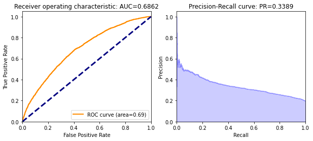

```python
best_rf_model = rf_grid1_perf.models[0]
ROC_AUC(best_rf_model, test_hex, 'loan_default')
```

```python
createGains(best_rf_model)
```

```
drf prediction progress: |████████████████████████████████████████████████| 100%
```

| decile | count | actual | non_actual | cum_count | cum_actual | cum_non_actual | percent_cum_actual | percent_cum_non_actual | if_random | lift | K_S | gain |
| --- | --- | --- | --- | --- | --- | --- | --- | --- | --- | --- | --- | --- |
| 0 | 1600 | 655 | 945 | 1600 | 655 | 945 | 0.21 | 0.07 | 310.0 | 2.11 | 14.0 | 40.94 |
| 1 | 1600 | 467 | 1133 | 3200 | 1122 | 2078 | 0.36 | 0.16 | 620.0 | 1.81 | 20.0 | 35.06 |
| 2 | 1600 | 419 | 1181 | 4800 | 1541 | 3259 | 0.50 | 0.25 | 930.0 | 1.66 | 25.0 | 32.10 |
| 3 | 1600 | 378 | 1222 | 6400 | 1919 | 4481 | 0.62 | 0.35 | 1240.0 | 1.55 | 27.0 | 29.98 |
| 4 | 1600 | 291 | 1309 | 8000 | 2210 | 5790 | 0.71 | 0.45 | 1550.0 | 1.43 | 26.0 | 27.62 |
| 5 | 1600 | 265 | 1335 | 9600 | 2475 | 7125 | 0.80 | 0.55 | 1860.0 | 1.33 | 25.0 | 25.78 |
| 6 | 1600 | 229 | 1371 | 11200 | 2704 | 8496 | 0.87 | 0.66 | 2170.0 | 1.25 | 21.0 | 24.14 |
| 7 | 1600 | 169 | 1431 | 12800 | 2873 | 9927 | 0.93 | 0.77 | 2480.0 | 1.16 | 16.0 | 22.45 |
| 8 | 1600 | 152 | 1448 | 14400 | 3025 | 11375 | 0.98 | 0.88 | 2790.0 | 1.08 | 10.0 | 21.01 |
| 9 | 1600 | 75 | 1525 | 16000 | 3100 | 12900 | 1.00 | 1.00 | 3100.0 | 1.00 | 0.0 | 19.38 |

While the model has provided similar results to the base model we built, we will use the parameters identified here while building models with under sampling the dataset.

## Undersampling dataset to improve model performance

In this section, we will use undersampling techniques to equalize the percentage of defaulted loans and non-defaulted loans in the training datasets. We also tried modelling with defaulted loans being twice, 1/3 and 1/4 the non-defaulted loans. However, having a 1:2 ration provided the best performance.

```python
y = train[target]
X = train.drop(target,axis=1)
y1_cnt = train[target].sum()
N = 2
y0_cnt = y1_cnt * N
```

USing imblearn's make_imbalance function we create the right sampled mix of data and concatenate it into a dataframe.

```python
from imblearn.datasets import make_imbalance
X_rs, y_rs = make_imbalance(X, y,
                            sampling_strategy={1:y1_cnt , 0:  y0_cnt},
                            random_state=0)
X_rs = pd.DataFrame(X_rs)
y_rs = pd.DataFrame(y_rs)
smpl = pd.concat([X_rs,y_rs], axis = 1)
smpl_hex = h2o.H2OFrame(smpl)

test2 = test.copy()
test2['loan_default'] = test2['loan_default'].astype('category')
test2_hex = h2o.H2OFrame(test2)
```

```
Parse progress: |█████████████████████████████████████████████████████████| 100%
Parse progress: |█████████████████████████████████████████████████████████| 100%
```

```python
rf_model_sampling = H2ORandomForestEstimator(
        model_id = 'rf_model_sampling',
        ntrees = 200,
        nfolds=10,
        min_rows=100,
        seed=1234)
rf_model_sampling.train(predictors,target,training_frame=smpl_hex)
```

```
drf Model Build progress: |███████████████████████████████████████████████| 100%
```

```
drf prediction progress: |████████████████████████████████████████████████| 100%

   * ROC curve: The ROC curve plots the true positive rate vs. the false rositive sate

	  * The area under the curve (AUC): A value between 0.5 (random) and 1.0 (perfect), measuring the prediction accuracy

   * Recall (R) = The number of true positives / (the number of true positives + the number of false negatives)
```

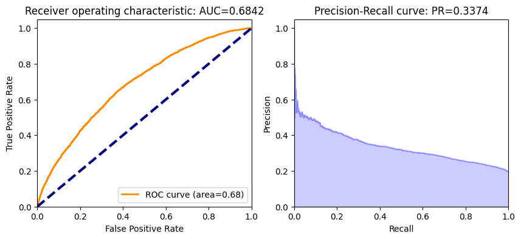

```python
ROC_AUC(rf_model_sampling, test2_hex, 'loan_default')
```

```python
createGains(rf_model_sampling)
```

```
drf prediction progress: |████████████████████████████████████████████████| 100%
```

[output not shown]

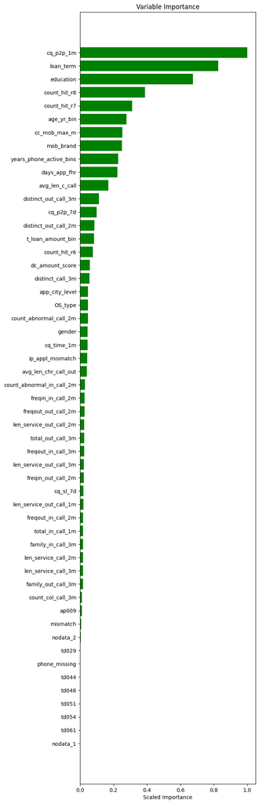

```python
VarImp(rf_model_sampling)
```

As expected our binned features and education, loan term and prior credit checks are all important variables in our model!